# DNA Kit Comparison in Urine

Lisa Karstens, PhD

07/24/2020

### Overview

This study investigates the impact of DNA extraction method on the microbial composition of urine samples evaluated by 16S rRNA amplicon sequencing. Details of the experimental design and methods can be found in the manuscript [Benchmarking DNA isolation kits used in analyses of the urinary microbiome](https://www.nature.com/articles/s41598-021-85482-1). Briefly, eleven voided urine samples were collected from women. The urine was pelleted, resuspended, and divided into five aliquots. Each aliquot was subject to DNA extraction by a different commercially available DNA extraction kit prior to being prepared for 16S rRNA amplicon sequencing of the V4 region.

| Kit code | Kit name |
| --- | --- |
| BandT | DNeasy Blood and Tissue |
| Biostic | BiOstic Bacteremia |
| PromegaSoil | DNeasy PowerSoil |
| PromegaMaxwell | Promega Maxwell RSC |
| UltraClean | DNeasy UltraClean |

This R Markdown file documents the analyses presented in the manuscript.

#### Set up workspace - load packages and data

```r
library(knitr)
library(phyloseq)
library(speedyseq)
library(ggplot2)
library(dplyr)
library(vegan)
library(here)
library(wesanderson)
library(plotly)
library(purrr)
library(tidyr)
library(tibble)
library(patchwork)
library(kableExtra)

load(here("dna_kits_urine.RData"))
```

This RData file has several objects in the workspace:

- ps - a phyloseq object with the microbiome data (ASV table, taxonomy table, and sample data table). This data was generated by running the raw sequencing data through DADA2 in R.
- ps_genus - a phyloseq agglomerated at the genus level with tax_glom.
- meta - a data.frame that contains the sample_data for the samples.
- color_map - a data.frame that we use for mapping desired colors for figure 3B
- create_group - a function we created for plotting our phyloseq data in an organized manner (Note, if you like figure 3B, you can now create similar plots on your own data with our microshades R package available [here](https://github.com/KarstensLab/microshades)).

### Update and manipulate data

We perform a few minor manipulations for the downstream analysis - subsetting the meta variable to remove the negative control and normalizing the phyloseq objects to relative abundance for visualization.

```r
# Create a subset without sample 12 (blank control samples):
meta_samples <- meta %>% filter(sample_number != 12)

# Create phyloseq objects normalized to 100
ps_norm <- transform_sample_counts(ps, function(x) 100* x/sum(x))
ps_norm_genus <- transform_sample_counts(ps_genus, function(x) 100* x/sum(x))
```

### DNA concentration per sample by Kit

First, we evaluate if the DNA concentration varies by kit.

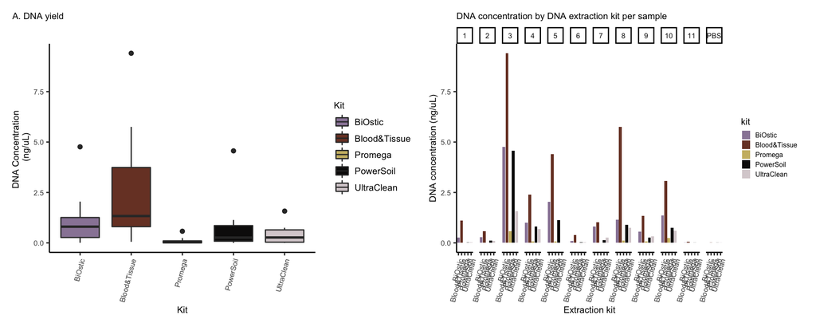

```r
# **Figures: of DNA Concentration** Figure 1A and Supplemental Figure 1

fig1_A <- meta %>% filter(sample_number != "PBS") %>%
  ggplot(., aes(x= kit, y = Qubit_Conc))  +
  theme_classic() +
  geom_boxplot(aes(fill = kit))  +
  labs(y = 'DNA Concentration \n (ng/uL)', x = 'Kit', fill = "Kit") +
  ggtitle('A. DNA yield') +
  scale_fill_manual(values = wes_palette("IsleofDogs1")) +
 theme(
      axis.text.x = element_text(angle = 75, hjust = 1),
      text = element_text(size=8),
      plot.title = element_text(size = 8),
      plot.title.position = "plot",
      axis.title=element_text(size=8),
      legend.text = element_text(size = 8),
      legend.key.size = unit(1,"line"))

# Plot all data
fig_S1A <- ggplot(meta, aes(x = kit, y = Qubit_Conc, fill = kit)) +
  geom_bar(stat = 'identity') +
  theme_classic() +
  facet_grid(~sample_number) +
  ggtitle('DNA concentration by DNA extraction kit per sample') +
  labs(y = 'DNA concentration (ng/uL)', x = 'Extraction kit') +
  theme(
    axis.text.x = element_text(angle = 75, hjust = 1),
    text = element_text(size=8), plot.title = element_text( size = 8 ),
    legend.text = element_text(size = 6),
    legend.key.size = unit(.6,"line")) +
  scale_fill_manual(values = wes_palette("IsleofDogs1"))

fig1_A + fig_S1A
```

```r
# Run kruskal-wallis test to determine if DNA concentration varies by kit
kruskal.test(Qubit_Conc ~ kit, data = meta_samples)
```

```
##
##  Kruskal-Wallis rank sum test
##
## data:  Qubit_Conc by kit
## Kruskal-Wallis chi-squared = 18.992, df = 4, p-value = 0.0007887
```

```r
# Significant, run post-hoc tests
pairwise.wilcox.test(meta_samples$Qubit_Conc, meta_samples$kit, p.adj = "none")
```

```
##
##  Pairwise comparisons using Wilcoxon rank sum exact test
##
## data:  meta_samples$Qubit_Conc and meta_samples$kit
##
##              BiOstic Blood&Tissue Promega PowerSoil
## Blood&Tissue 0.15997 -            -       -
## Promega      0.00316 0.00067      -       -
## PowerSoil    0.34736 0.03872      0.01341 -
## UltraClean   0.14865 0.00829      0.05022 0.47758
##
## P value adjustment method: none
```

#### Summary of results- DNA concentration by kit

There is a significant difference between the amount of DNA extracted from each sample and the DNA kit used. Specifically, there was a significant difference in the amount of DNA extracted from the Blood and Tissue Kit and the Promega Maxwell kit, Promega Soil, and UltraClean kit.

Note - sample 12 was removed from the statistical analysis since it is the negative extraction blank and not an actual sample.

### Sequencing depth per sample by Kit

Next, we evaluate if the sequencing depth (number of sequencing reads) vary by kit used.

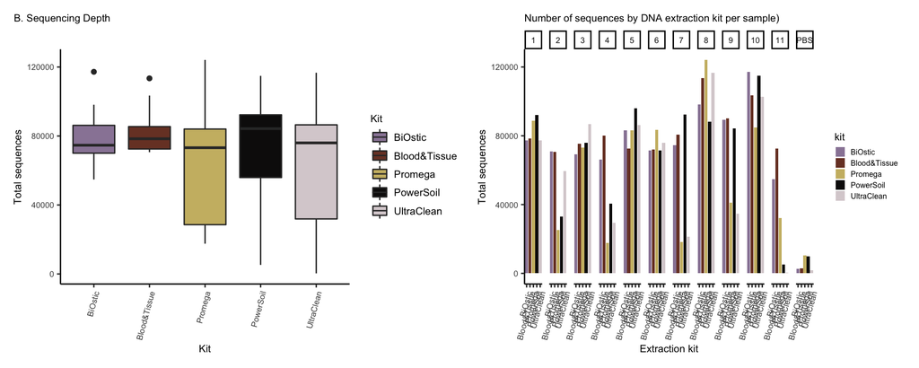

```r
# **Figures:** Figure 1B and Supplemental Figure 2

fig1_B <- meta %>% filter(sample_number != "PBS") %>%
  ggplot(., aes(x=kit, y = TotalReads))  +
  theme_classic() +
  geom_boxplot(aes(fill = kit))  +
  labs(y = 'Total sequences', x = 'Kit', fill = "Kit") +
  ggtitle('B. Sequencing Depth') +
  scale_fill_manual(values = wes_palette("IsleofDogs1")) +
  theme(
      axis.text.x = element_text(angle = 75, hjust = 1),
      text = element_text(size=8),
      plot.title = element_text(size = 8),
      plot.title.position = "plot",
      axis.title=element_text(size=8),
      legend.text = element_text(size = 8),
      legend.key.size = unit(1,"line"))


# plot Total Reads by kit
fig_S1B <- meta  %>%
  ggplot(., aes(x = kit, y = TotalReads, fill = kit)) +
    geom_bar(stat = 'identity') + facet_grid(~sample_number) +
    ggtitle('Number of sequences by DNA extraction kit per sample)') +
    labs(y = 'Total sequences', x = 'Extraction kit') +
    scale_fill_manual(values = wes_palette("IsleofDogs1")) +
    theme_classic() +
    theme(
      axis.text.x = element_text(angle = 75, hjust = 1),
      text = element_text(size=8), plot.title = element_text( size = 8 ),
      legend.text = element_text(size = 6),
      legend.key.size = unit(.6,"line"))

fig1_B + fig_S1B
```

```r
# Run kruskal-wallis test
kruskal.test(TotalReads ~ kit, data = meta_samples)
```

```
##
##  Kruskal-Wallis rank sum test
##
## data:  TotalReads by kit
## Kruskal-Wallis chi-squared = 1.6148, df = 4, p-value = 0.8061
```

```r
# not significant
```

#### Summary of results-number of reads per sample by Kit

There was no significant difference between the number of reads per sample and DNA extraction kit used, though the Promega Maxwell, Promega Soil, and Ultraclean did have less than 50% of the total number of reads compared to the Biostic and DNEasy Blood and Tissue kits for a subset of samples (3, 2, and 3 respectively).

### Evaluate alpha diversity

Next, we evaluate alpha diversity metrics - summary measures commonly used in microbiome science to compare the numbers and distribution of bacteria in a given sample. We will use the number of observed genera, Shannon index, and Inverse Simpson index and identify if there are significant differences depending on which kit was used for DNA extraction.

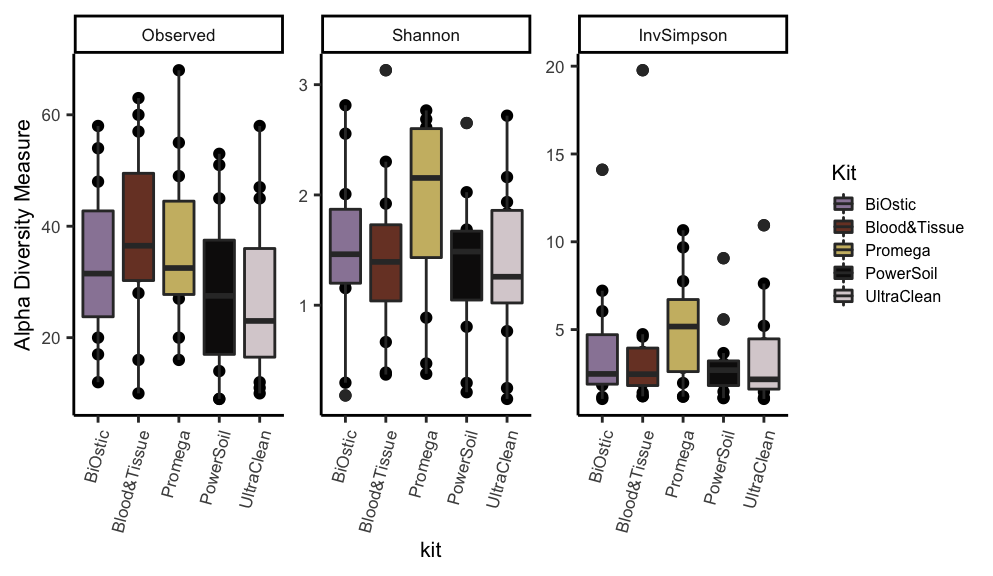

```r
# **Figures** - Alpha diversity

fig2 <- plot_richness(ps_genus, x = "kit", measures = c("Observed", "Shannon", "InvSimpson")) +
  scale_fill_manual(values = wes_palette("IsleofDogs1"))  +
  geom_boxplot(aes(fill = kit))  +
  theme_classic() +
    theme(
      axis.text.x = element_text(angle = 75, hjust = 1),
      text = element_text(size=8), plot.title = element_text( size = 8 ),
      legend.text = element_text(size = 6),
      legend.key.size = unit(.6,"line")) +
      labs(fill = "Kit")

fig2
```

```r
alpha_measures <- estimate_richness(ps_genus, measures = c("Observed", "Shannon", "InvSimpson"))

test_frame <- data.frame(observed=alpha_measures$Observed, shannon = alpha_measures$Shannon, inv_simpson = alpha_measures$InvSimpson, kit = factor(sample_data(ps_genus)$kit))

# test for normality
shapiro.test(test_frame$observed)
```

```
##
##  Shapiro-Wilk normality test
##
## data:  test_frame$observed
## W = 0.96335, p-value = 0.0687
```

```r
shapiro.test(test_frame$shannon)
```

```
##
##  Shapiro-Wilk normality test
##
## data:  test_frame$shannon
## W = 0.96742, p-value = 0.1089
```

```r
shapiro.test(test_frame$inv_simpson)
```

```
##
##  Shapiro-Wilk normality test
##
## data:  test_frame$inv_simpson
## W = 0.75634, p-value = 1.282e-08
```

```r
kruskal.test(observed ~ kit, data = test_frame)
```

```
##
##  Kruskal-Wallis rank sum test
##
## data:  observed by kit
## Kruskal-Wallis chi-squared = 4.9591, df = 4, p-value = 0.2915
```

```r
kruskal.test(shannon ~ kit, data = test_frame)
```

```
##
##  Kruskal-Wallis rank sum test
##
## data:  shannon by kit
## Kruskal-Wallis chi-squared = 4.3279, df = 4, p-value = 0.3634
```

```r
kruskal.test(inv_simpson ~ kit, data = test_frame)
```

```
##
##  Kruskal-Wallis rank sum test
##
## data:  inv_simpson by kit
## Kruskal-Wallis chi-squared = 3.7814, df = 4, p-value = 0.4364
```

#### Summary of Results - Alpha Diversity

There are no significant differences in alpha diversity measured by the number of observed genera, the Shannon index, or the inverse Simpson index per sample across kits.

### Overview - Microbial composition

To get an idea of the types and distribution of bacteria in each sample, we will visualize the data as stacked bar plots (normalized to relative abundance) and summarize a beta diversity analysis.

For the stacked bar plots, we will use a coloring scheme that uses the hierarchical structure of microbiome data and color each Phylum by a “parent” color, and the top 4 genera within each Phylum as a different shade of the parent color. Finally, all other genera that are grouped in an “other” category within each Phylum. To visually see the differences/similarities between kits, we facet (group) the stacked bar plots by subject (each subject in theory should have a very similar microbiome profile regardless of kit).

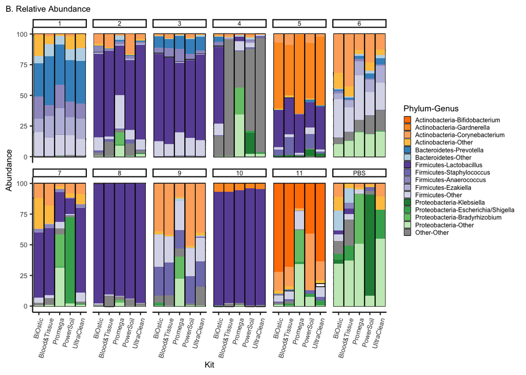

```r
ps_norm_genus_top <- create_group(ps_norm_genus, color_map)

fig3_B <- plot_bar(ps_norm_genus_top, x = "kit", fill = 'group')  +
      scale_fill_manual( values = color_map$hex, breaks = color_map$group) +
     geom_bar(stat = "identity") +
        facet_wrap(~sample_number, ncol = 6) +
        theme_classic() +
    theme(
      axis.text.x = element_text(angle = 75, hjust = 1),
      text = element_text(size=8),
      plot.title = element_text( size = 8 ),
       plot.title.position = "plot",
      legend.text = element_text(size = 6),
      legend.key.size = unit(.5,"line"),
      strip.text.x = element_text(size = 6, margin = margin(.05, 0, .05, 0, "cm" ))) +
    labs(fill = "Phylum-Genus") +
    xlab('Kit') +
    guides(fill = guide_legend(ncol = 1)) +
    ggtitle('B. Relative Abundance')


fig3_B
```

To further evaluate and summarize how different each microbiome sample is from each other, we will use the Bray-Curtis dissimilarity metric and MDS. We will test for significant effects using adonis.

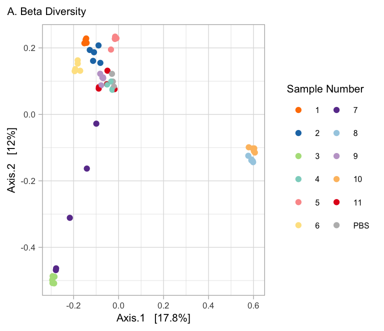

```r
out.wuf <- ordinate(ps, method = "MDS", distance = "bray")

asv_table <- as.data.frame(ps@otu_table)
meta <- as.data.frame(as.matrix(sample_data(ps)))

# **Figures** Beta Diversity

# define colors
color_palette <- c(`1` ="#FF7F00", `2` ="#1F78B4" , `3` = "#B2DF8A", `4` =  "#8dd3c7", `5` =  "#FB9A99" ,`6` = "#FEE391", `7`= "#6A3D9A", `8` ="#A6CEE3" , `9` = "#c2a5cf", `10`= "#FDBF6F", `11` =  "#E31A1C", `PBS` = "#BABABA")

fig3_A <- plot_ordination(ps, out.wuf, color = "sample_number") +
  ggtitle('A. Beta Diversity') +
  geom_point(size = 1) +
  scale_color_manual(values = color_palette, name = 'Sample Number') +
  theme_light() +
  theme(
      text = element_text(size=8),
      plot.title = element_text( size = 8 ),
      plot.title.position = "plot",
      legend.text = element_text(size = 6),
      legend.position="right") +
  guides(color = guide_legend(ncol = 2))

fig3_A
```

```r
adonis (formula = asv_table ~  sample_number, data = meta)
```

```
##
## Call:
## adonis(formula = asv_table ~ sample_number, data = meta)
##
## Permutation: free
## Number of permutations: 999
##
## Terms added sequentially (first to last)
##
##               Df SumsOfSqs MeanSqs F.Model      R2 Pr(>F)
## sample_number 11   18.3253 1.66593  10.273 0.70187  0.001 ***
## Residuals     48    7.7838 0.16216         0.29813
## Total         59   26.1091                 1.00000
## ---
## Signif. codes:  0 '***' 0.001 '**' 0.01 '*' 0.05 '.' 0.1 ' ' 1
```

```r
adonis (formula = asv_table ~  kit, data = meta)
```

```
##
## Call:
## adonis(formula = asv_table ~ kit, data = meta)
##
## Permutation: free
## Number of permutations: 999
##
## Terms added sequentially (first to last)
##
##           Df SumsOfSqs MeanSqs F.Model      R2 Pr(>F)
## kit        4    1.4224 0.35561 0.79228 0.05448   0.87
## Residuals 55   24.6866 0.44885         0.94552
## Total     59   26.1091                 1.00000
```

#### Summary of Results - Beta Diversity

Beta diversity did not significantly differ by kit (p=0.870), but did by subject (p = 0.001), which is expected since individuals typically have distinct microbiomes from each other. Further, in the MDS plots, it is obvious that, for most subjects, the samples clustered together regardless of kit used for DNA extraction. The exception to this was sample 7, which had a great deal of variation across the DNA kit used.

The initial overview of the phyloseq object shows that some samples have approximately equal read depths across all kits (samples 1, 3, 5, 6, 8, 10), but others have quite varying depths (2, 4, 7, 9, 11). One sample has a low depth across all kits (12, PBS negative control).

### Gram positive vs Gram negative

We are interested in whether there is a difference in gram positive or gram negative bacteria represented from different kits. Note, for this analysis we annotated the tax_table with a column indicating if each genera was gram positive/gram negative/ gram variable/ or unknown.

```r
## Remove blanks from analysis
ps_norm <- subset_samples(ps_norm, sample_number != "PBS")

# Agglomerate tax_table at the gram level
ps_norm_gram <- tax_glom(ps_norm, 'gram')

# create phyloseq objects for each subset
ps_gram_pos <- subset_taxa(ps_norm_gram, gram == 'positive')
ps_gram_neg <- subset_taxa(ps_norm_gram, gram == 'negative')
ps_gram_other <- subset_taxa(ps_norm_gram, gram != 'positive')
ps_gram_other <- subset_taxa(ps_gram_other, gram != 'negative')

# summarize into a datatable
gram_summary <- cbind(positive = sample_sums(ps_gram_pos),negative = sample_sums(ps_gram_neg), other = sample_sums(ps_gram_other))

ps_gram_summary <- phyloseq(otu_table(gram_summary, taxa_are_rows = FALSE), sample_data(meta))

ps_gram_melt <- psmelt(ps_gram_summary)

gram_positive <-  ps_gram_melt %>% filter(OTU == 'positive')

print('Test for differences in gram positive bacteria by kit')
```

```
## [1] "Test for differences in gram positive bacteria by kit"
```

```r
kruskal.test(Abundance ~ kit, gram_positive)
```

```
##
##  Kruskal-Wallis rank sum test
##
## data:  Abundance by kit
## Kruskal-Wallis chi-squared = 6.0283, df = 4, p-value = 0.197
```

```r
pairwise.wilcox.test(gram_positive$Abundance, gram_positive$kit, p.adj = "none")
```

```
##
##  Pairwise comparisons using Wilcoxon rank sum exact test
##
## data:  gram_positive$Abundance and gram_positive$kit
##
##              BiOstic Blood&Tissue PowerSoil Promega
## Blood&Tissue 0.332   -            -         -
## PowerSoil    0.332   0.797        -         -
## Promega      0.013   0.171        0.300     -
## UltraClean   0.606   0.748        0.748     0.101
##
## P value adjustment method: none
```

```r
pairwise.wilcox.test(gram_positive$Abundance, gram_positive$kit, p.adj = "fdr")
```

```
##
##  Pairwise comparisons using Wilcoxon rank sum exact test
##
## data:  gram_positive$Abundance and gram_positive$kit
##
##              BiOstic Blood&Tissue PowerSoil Promega
## Blood&Tissue 0.55    -            -         -
## PowerSoil    0.55    0.80         -         -
## Promega      0.13    0.55         0.55      -
## UltraClean   0.80    0.80         0.80      0.51
##
## P value adjustment method: fdr
```

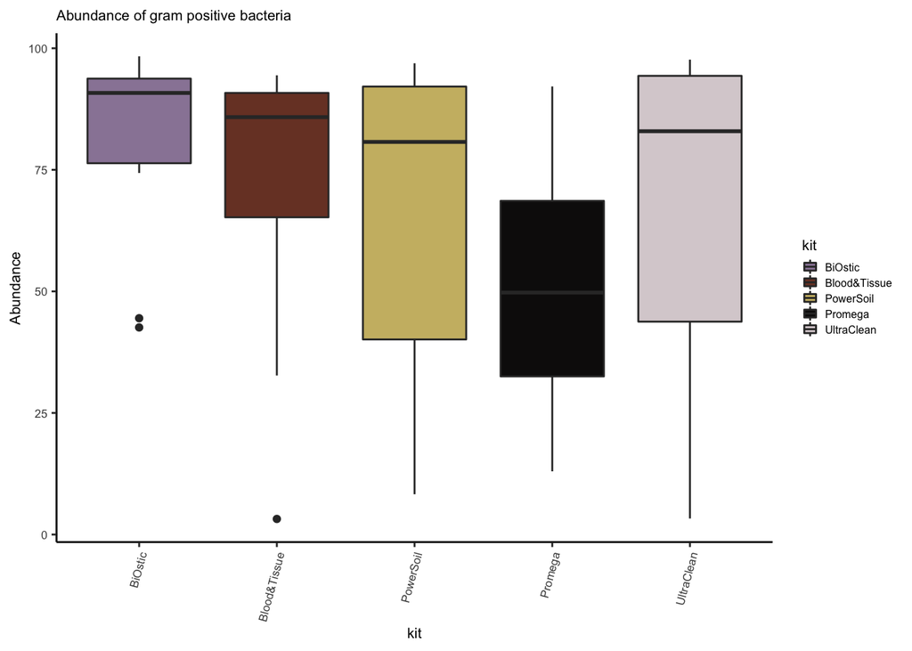

```r
fig4 <- ps_gram_melt %>%
  filter(OTU == 'positive') %>%
  ggplot( aes(x= kit,
             y=Abundance,
             fill = kit)) +
      geom_boxplot()  +
      ggtitle('Abundance of gram positive bacteria')  +
    scale_fill_manual(values = wes_palette("IsleofDogs1"))+
    theme_classic() +
    theme(
    axis.text.x = element_text(angle = 75, hjust = 1),
    text = element_text(size=8), plot.title = element_text( size = 8 ),
    legend.text = element_text(size = 6),
    legend.key.size = unit(.6,"line"))

fig4
```

#### Summary of results - gram positive bacteria

Based on the above results, it does appear that some DNA kits have increased variability and the the Promega kit recovered fewer Gram positive bacteria than the other kits, though this was not significantly different (Kruskal–Wallis, p = 0.197).

### Evaluate Variation in Select Bacteria

We are also interested in if there are differences between bacteria that are known to be uropathogens or are potential commensals.

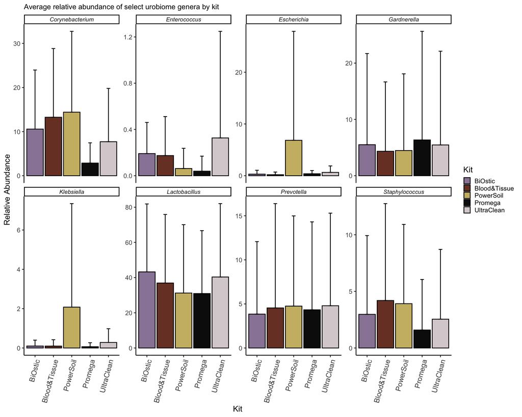

```r
ps_Lactobacillus <- subset_taxa(ps_norm, Genus == "Lactobacillus")
ps_Prevotella <-  subset_taxa(ps_norm, Genus == "Prevotella")
ps_Gardnerella <-  subset_taxa(ps_norm, Genus == "Gardnerella")
ps_Escherichia <- subset_taxa(ps_norm, Genus == "Escherichia/Shigella")
ps_Enterococcus <- subset_taxa(ps_norm, Genus == "Enterococcus")
ps_Corynebacterium <-  subset_taxa(ps_norm, Genus == "Corynebacterium")
ps_Klebsiella <-  subset_taxa(ps_norm, Genus == "Klebsiella")
ps_Staphylococcus <- subset_taxa(ps_norm, Genus == "Staphylococcus")

select_summary <- cbind(Lactobacillus = sample_sums(ps_Lactobacillus),Prevotella = sample_sums(ps_Prevotella), Gardnerella = sample_sums(ps_Gardnerella), Escherichia = sample_sums(ps_Escherichia), Staphylococcus = sample_sums(ps_Staphylococcus), Klebsiella = sample_sums(ps_Klebsiella), Corynebacterium = sample_sums(ps_Corynebacterium), Enterococcus = sample_sums(ps_Enterococcus) )

ps_select_taxa  <- phyloseq(otu_table(select_summary, taxa_are_rows = FALSE), sample_data(meta))

ps_taxa_melt <- psmelt(ps_select_taxa)

taxa_summary <- ps_taxa_melt %>%
  group_by(OTU, kit) %>%
   summarise(
    sd = sd(Abundance, na.rm = TRUE),
    mean_abd = mean(Abundance),
    med_abd = median(Abundance))


fig5 <- ggplot(taxa_summary, aes(kit,mean_abd , fill = kit)) +
  geom_bar(stat = "identity", color = "black") +
  geom_errorbar(aes(ymin = mean_abd, ymax = mean_abd+sd), width = 0.2) +
  scale_fill_manual(values = wes_palette("IsleofDogs1")) +
  facet_wrap(~OTU, scales = 'free_y', ncol= 4) +
  ggtitle('Average relative abundance of select urobiome genera by kit ') +
  labs(y = 'Relative Abundance', x = 'Kit', fill = "Kit") +
  theme_classic() +
  theme(
    axis.text.x = element_text(angle = 75, hjust = 1, size = 10),
    plot.title = element_text( size = 10 ),
    legend.key.size = unit(.7,"line"),
    strip.text.x = element_text(size = 8, margin = margin(.1, 0, .1, 0, "cm" ), face = "italic"))
fig5
```

Calculate stats of differences of individual bacteria per kit

```r
ind_bact_test <- ps_taxa_melt %>%
  select(OTU, Abundance, kit) %>%
  nest(-OTU) %>%
  mutate(model = map(data, ~kruskal.test(Abundance ~ kit, .)),
         tidy = map(model, broom::tidy)) %>%
select(OTU, tidy) %>%
unnest(.)

ind_bact_test %>%
  select(OTU, p.value) %>%
  kable(caption = 'Kruskal-Wallis test of bacterial abundance by kit') %>%
  kable_styling()
```

Kruskal-Wallis test of bacterial abundance by kit

| OTU | p.value |
| --- | --- |
| Lactobacillus | 0.9724062 |
| Escherichia | 0.3146390 |
| Gardnerella | 0.9914122 |
| Corynebacterium | 0.2200768 |
| Prevotella | 0.9840616 |
| Staphylococcus | 0.4374412 |
| Klebsiella | 0.4604939 |
| Enterococcus | 0.1021204 |

```r
# explore select individual bacteria with pair-wise comparisons
ps_taxa_melt %>%
  filter(OTU == "Enterococcus") %>%
  with(., pairwise.wilcox.test(Abundance, kit, p.adjust.method = "none"))
```

```
##
##  Pairwise comparisons using Wilcoxon rank sum test with continuity correction
##
## data:  Abundance and kit
##
##              BiOstic Blood&Tissue PowerSoil Promega
## Blood&Tissue 0.581   -            -         -
## PowerSoil    0.115   0.361        -         -
## Promega      0.018   0.079        0.329     -
## UltraClean   0.105   0.302        0.788     0.509
##
## P value adjustment method: none
```

#### Summary of Results - Individual bacteria

Overall, we found a few differences in recovery of specific bacteria, though none of these findongs were significant in our small sample. The Promega kit tended to recover fewer Gram positive bacteria (Corynebacteria, Enterococci, and Staphylococci) and the PowerSoil kit recovered more Escherichia and Klebsiella compared to other kits.